# Estimativas Populacionais Brasil

O Brasil é um país continental, com uma população estimada de 213 milhões de habitantes, em um território de 8,5 milhões de Km².

De grandes aglomerados populacionais, como Brasília e São Paulo, até a Floresta Amazônica, temos grandes diferenças na distribuição populacional ao longo de todo o território. Para entendermos melhor estas diferenças, construí este **notebook** utilizando [RMarkdown](https://rmarkdown.rstudio.com) e [RStudio](https://www.rstudio.com).

**Este notebook está disponível em meu [GitHub](https://github.com/epklein/EstimativasPopulacionais-Brasil)**.

Os dados utilizados são oficiais do IBGE, disponíveis nos seguintes links:

- Estimativas populacionais de 2021: https://www.ibge.gov.br/estatisticas-novoportal/sociais/populacao/9103-estimativas-de-populacao.html
- Área territorial do Brasil, Regiões e Unidades Federativas: https://ww2.ibge.gov.br/home/geociencias/areaterritorial/principal.shtm

# Dados populacionais e demográficos do Brasil

A tabela a seguir, com a consolidação dos dados do IBGE, exibe a População e Área de cada uma das Unidades da Federação.

```r
# data.frame das unidades federativas do país
dfFedUnits
```

```
##                   Unit              Region Population        Area
## 1                 Acre        Região Norte     906876  164123.737
## 2              Alagoas     Região Nordeste    3365351   27848.140
## 3                Amapá        Região Norte     877613  142828.521
## 4             Amazonas        Região Norte    4269995 1559146.876
## 5                Bahia     Região Nordeste   14985284  564732.450
## 6                Ceará     Região Nordeste    9240580  148887.633
## 7     Distrito Federal Região Centro-Oeste    3094325    5779.997
## 8       Espírito Santo      Região Sudeste    4108508   46086.907
## 9                Goiás Região Centro-Oeste    7206589  340106.492
## 10            Maranhão     Região Nordeste    7153262  331936.949
## 11         Mato Grosso Região Centro-Oeste    3567234  903202.446
## 12  Mato Grosso do Sul Região Centro-Oeste    2839188  357145.531
## 13        Minas Gerais      Região Sudeste   21411923  586520.732
## 14                Pará        Região Norte    8777124 1247955.238
## 15             Paraíba     Região Nordeste    4059905   56468.435
## 16              Paraná          Região Sul   11597484  199307.939
## 17          Pernambuco     Região Nordeste    9674793   98076.021
## 18               Piauí     Região Nordeste    3289290  251611.929
## 19      Rio de Janeiro      Região Sudeste   17463349   43781.588
## 20 Rio Grande do Norte     Região Nordeste    3560903   52811.107
## 21   Rio Grande do Sul          Região Sul   11466630  281737.888
## 22            Rondônia        Região Norte    1815278  237765.293
## 23             Roraima        Região Norte     652713  224300.805
## 24      Santa Catarina          Região Sul    7338473   95737.954
## 25           São Paulo      Região Sudeste   46649132  248219.627
## 26             Sergipe     Região Nordeste    2338474   21918.443
## 27           Tocantins        Região Norte    1607363  277720.412
```

A próxima tabela exibe População e Área consolidados pelas Regiões Brasileiras, o que nos permitirá traçar os contrastes.

```r
# data.frame das regiões do país
dfRegions <- aggregate(list(Population=dfFedUnits$Population,
                            Area=dfFedUnits$Area),
                       list(Region=dfFedUnits$Region),
                       sum)

dfRegions
```

```
##                Region Population      Area
## 1        Região Norte   18906962 3853840.9
## 2     Região Nordeste   57667842 1554291.1
## 3      Região Sudeste   89632912  924608.9
## 4          Região Sul   30402587  576783.8
## 5 Região Centro-Oeste   16707336 1606234.5
```

# Estimativas populacionais e demográficas

Como a população brasileira está distribuída ao longo dos seus 26 estados e Distrito Federal? Vejamos o seguinte gráfico:

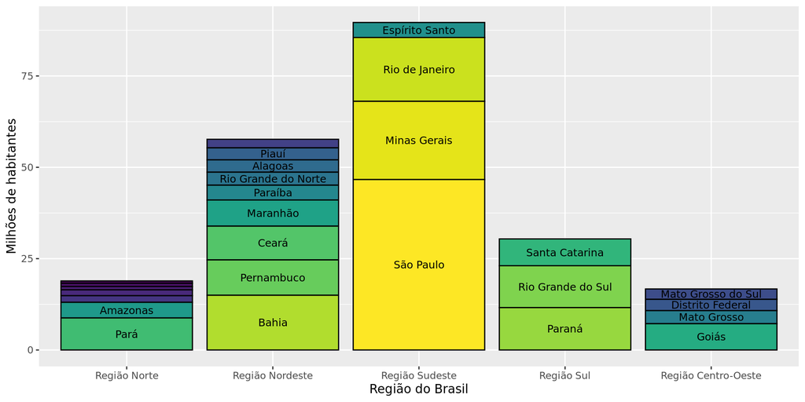

```r
# colunas ordenadas e filtradas para fins de plotagem de população
dfFedUnits$UnitOrdPop <- factor(dfFedUnits$Unit,
                                 levels=dfFedUnits$Unit[order(dfFedUnits$Population)],
                                 ordered=TRUE)
dfFedUnits$UnitNamePopPlot <- as.character(dfFedUnits$Unit)
dfFedUnits$UnitNamePopPlot[which(dfFedUnits$Population < 2.5E+6)] <- NA

ggplot(data=dfFedUnits,
       aes(x=Region, weights=Population / 1E+6)) +
  geom_bar(aes(fill=UnitOrdPop), color="Black") +
  geom_text(aes(x=Region, y=Population / 1E+6, group=UnitOrdPop, label=UnitNamePopPlot),
            position = position_stack(vjust = 0.5), size=3.3) +
  guides(fill=FALSE) +
  xlab("Região do Brasil") +
  ylab("Milhões de habitantes")
```

O contraste entre regiões é ainda maior quando se compara estes resultados com as áreas das regiões e Unidades Federativas, conforme o gráfico abaixo:

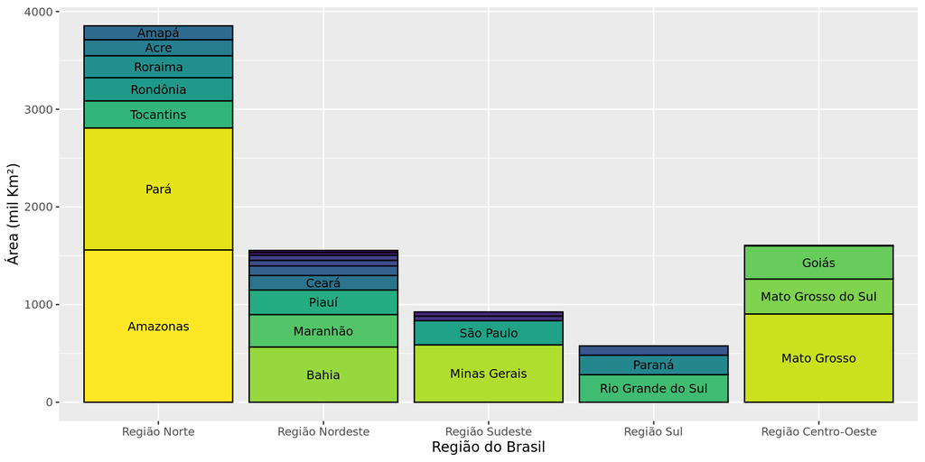

```r
# colunas ordenadas e filtradas para fins de plotagem de área territorial
dfFedUnits$UnitOrdArea <- factor(dfFedUnits$Unit,
                                 levels=dfFedUnits$Unit[order(dfFedUnits$Area)],
                                 ordered=TRUE)
dfFedUnits$UnitNameAreaPlot <- as.character(dfFedUnits$Unit)
dfFedUnits$UnitNameAreaPlot[which(dfFedUnits$Area < 1E+5)] <- NA

ggplot(data=dfFedUnits,
       aes(x=Region, weights=Area / 1E+3)) +
  geom_bar(aes(fill=UnitOrdArea), color="Black") +
  geom_text(aes(x=Region, y=Area / 1E+3, group=UnitOrdArea, label=UnitNameAreaPlot),
            position = position_stack(vjust = 0.5), size=3.3) +
  guides(fill=FALSE) +
  xlab("Região do Brasil") +
  ylab("Área (mil Km²)")
```

Enquanto a grande população da região Sudeste se concentra em menos de 1 milhão de Km² do território, a imensidão de território dos estados do Norte, seguidos do Centro-Oeste, destacam-se pela baixa concentração de população.

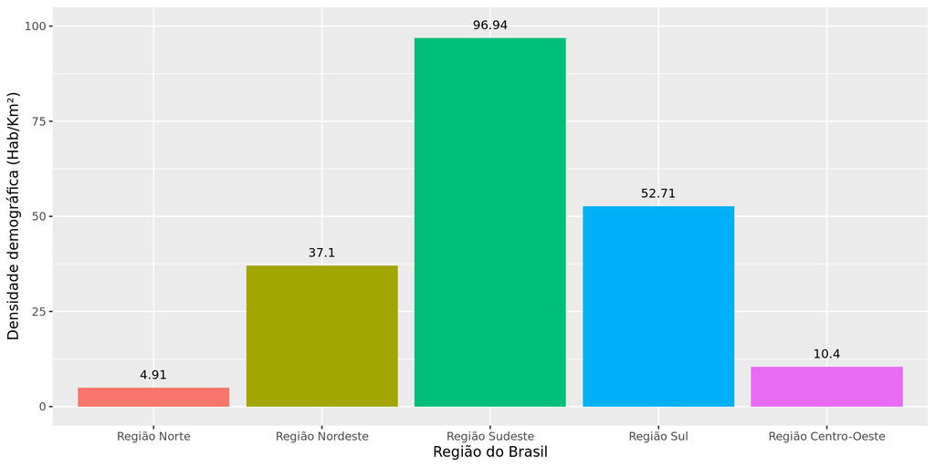

```r
ggplot(data=dfRegions, aes(x=Region)) +
  geom_col(aes(y=Population/Area, fill=Region)) +
  geom_text(aes(x=Region, y=Population / Area, label=round(Population / Area, 2)),
            size=3.3, vjust=-1) +
  guides(fill=FALSE) +
  ylim(0, 100) +
  xlab("Região do Brasil") + ylab("Densidade demográfica (Hab/Km²)")
```

Outra curiosidade, se o Brasil tivesse ao longo do seu território a mesma densidade demográfica da região Sudeste, então teríamos uma população de 800 milhões de brasileiros!